# Индивидуальный проект. Этап №1

Операционные системы

Дроздова Д. И.

Российский университет дружбы народов, Москва, Россия

# Информация

## Докладчик

- Дроздова Дарья Игоревна
- студентка НБИ-01
- Российский университет дружбы народов

## Цели и задачи

- Размещение на Github pages заготовки для персонального сайта.

## Материалы и методы

- Необходимое программное обеспечение.
- Шаблон темы сайта Hugo Academic Theme
- Генератор статических сайтов Hugo
- Общие файлы для тем Wowchemy

## Задание

- Установить необходимое программное обеспечение.
- Скачать шаблон темы сайта.
- Разместить его на хостинге git.
- Установить параметр для URLs сайта.
- Разместить заготовку сайта на Github pages.

# Выполнение первого этапа проекта

## Установим генератор статических сайтов Hugo по ссылке https://github.com/gohugoio/hugo/releases:

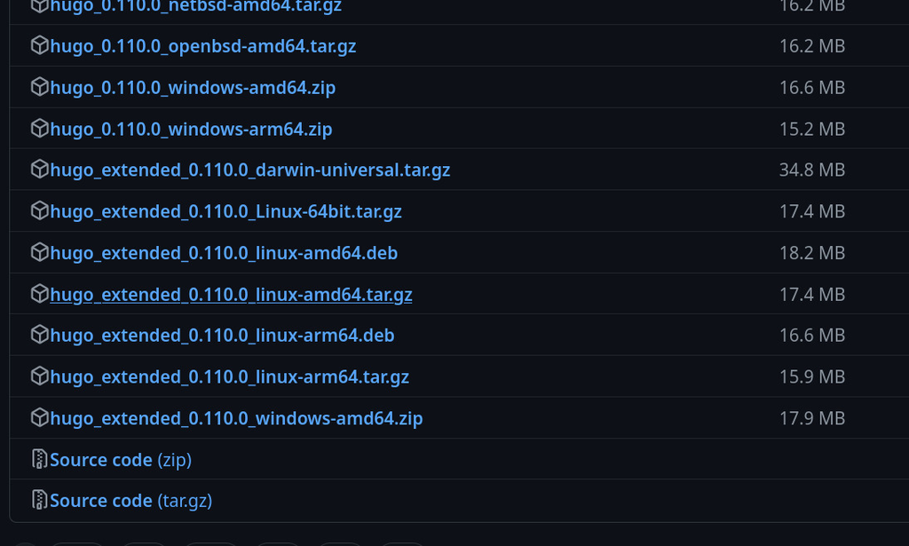

Установка Hugo

Выбираем расширенную версию

## После загрузки распаковываем zip-файл и из каталога ~/Загрузки/hugo_extended_0.110.0_Linux-64bit вырезаем *hugo*:

[figure not shown]

Переносим Hugo

## Клонируем репозиторий по ссылке https://github.com/wowchemy/starter-hugo-academic:

[figure not shown]

Клонируем репозиторий

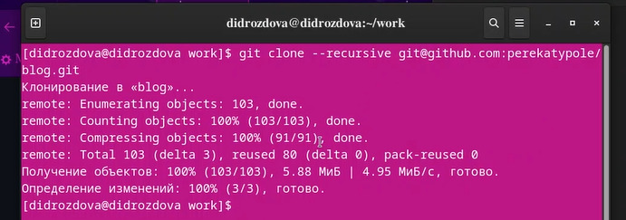

Локальный репозиторий

## Удаляем каталог ~/work/blog/public и проверяем выполнение этого действия:

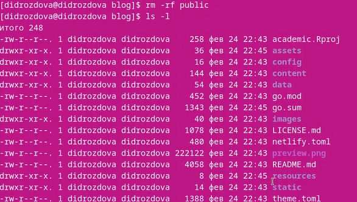

Удаляем каталог public

## Вводим ~/bin/hugo server, копируем сгенери рованную ссылку и открываем ее в браузере:

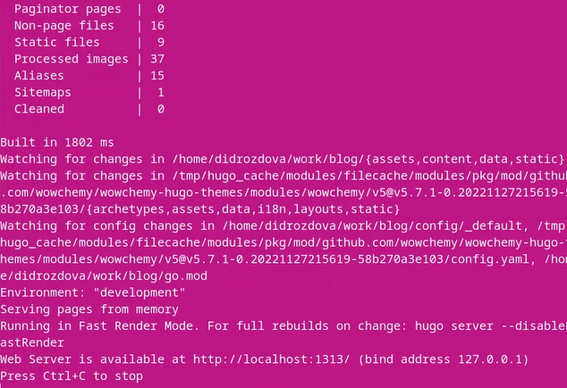

~/bin/hugo server

## Переходим в ~/work/blog/content/_index.md и удаляем блок “block:hero” с 8 по 37 строчку и сохраняем файл:

[figure not shown]

_index.md

Теперь на нашем сайте пропал синий фон.

## Создаем новый репозиторий на гитхабе *username.github.io* и копируем на него ссылку:

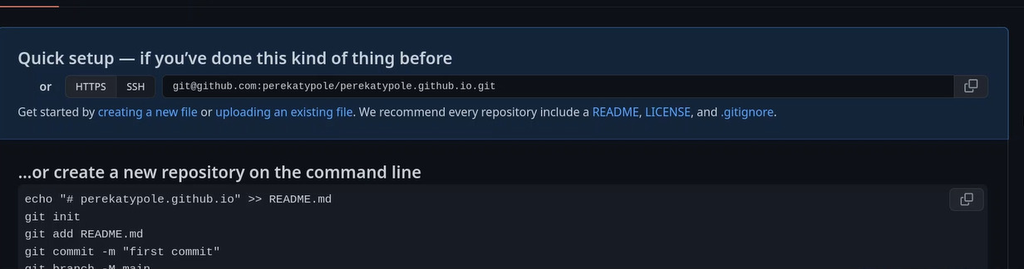

.github.io

## Переходим в ~/work и клонируем только что созданный репозиторий:

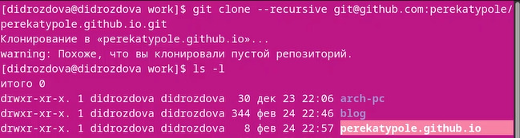

Клонируем только что созданный репозиторий

## Переходим в ~/work/username.github.io и переключаемся на ветку main:

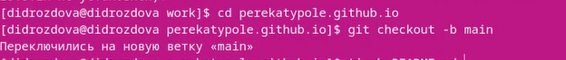

Ветка main

## Создаем README.MD, подготавливаем изменения к коммиту, создаем коммит и пушим изменения на сервер:

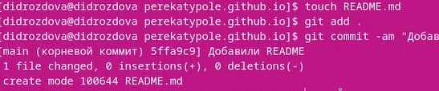

README.MD

## Переходим в ~/work/blog и создаем подрепозиторий:

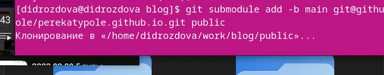

submodule

## Редактируем файл *.gitignore* в ~/work/blog(ставим “#” перед *public*):

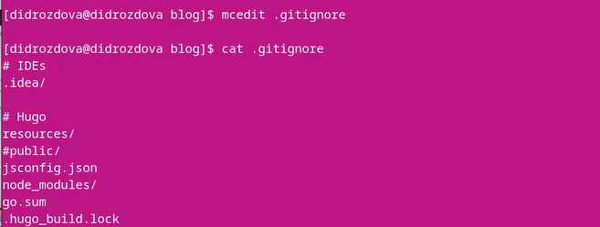

submodule

- После выполнения предыдущего шага снова выполняем команду, которая позволит нам сделать наш сайт доступным для других машин:

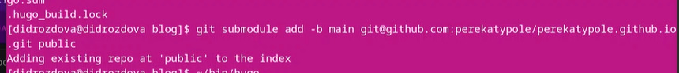

submodule public

## Проверяем соединение с репозиторием, подготовим изменения к коммиту, сделаем коммит и отправим изменения с локального репозиория:

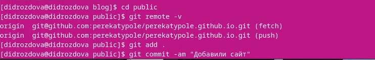

Добавили сайт

Первый этап индивидуального проекта выполнен.

# Выводы

Мы разместили на Github pages заготовки для персонального сайта.